# Jimmy’s Edits

## My comments

### 1!

Libraries, make them clear and easy to see! We should know what we need to download and what’s going to be used throughout the rmd!

```r
library(tidyverse)
library(curl)
```

### 2

Make sure that your rmd can be replicated whenever someone pulls from github (or whatever)! Having things saved onto desktops are fine but is much easier to use curl when collaborating.

### 3

Add some more comments! Makes it a bit easier to see what’s being calculated in each chunk.

### 4

I agree with you! sd() is so convenient, and you’re probably never going to be calculating population sd or mean because if you had the entire population, there wouldn’t be a need to be doing statistics/working w a sample.

### 5

The for loop situation you had going on is smart, and definitely the way to go for when replicate() doesn’t work out for whatever reason.

## Overall good first draft! I like your use of color for ggplot2, and although I can’t see plant vs. zombies image, I’m sure it’s great <3.

## Challenges

I had a more difficult time with this homework than the last two. Particularly I struggled with Q5 and Q6 as I was having trouble understanding the difference between population and sample standard deviation and mean. I also struggled with including my past sample in the collection of 99 new samples in Q6 and although I worked out the problem, I think there are more efficient ways of doing the same task.

I also struggled with calculating the standard deviation of the population as a whole without the sd() command. Once again I was able to resolve my issue, but think that there is a better way to go about it. I also think I used too many variables as I got lost sometimes remembering which ones to call for specific problems.

## Problem 1: Means

```r
knitr::opts_chunk$set(echo = TRUE) # you don't necessarily have to have this line in every chunk
height <- zombie_data[["height"]]
weight <- zombie_data[["weight"]]
killed <- zombie_data[["zombies_killed"]]
age <- zombie_data[["age"]]
years_of_education <- zombie_data[["years_of_education"]]
mean_height <- mean(height) # getting nitpicky but it's not really necessary to assign a variable to something as simple as mean
mean_height
```

```
## [1] 67.6301
```

```r
mean_weight <- mean(weight)
mean_weight
```

```
## [1] 143.9075
```

```r
mean_age <- mean(age)
mean_age
```

```
## [1] 20.04696
```

```r
mean_killed <- mean(killed)
mean(killed)
```

```
## [1] 2.992
```

```r
mean_years_of_education <- mean(years_of_education)
mean_years_of_education
```

```
## [1] 2.996
```

## Problem 1: Standard Deviations

```r
sum_squared_diff_age <- sum((age - mean_age)^2) # this is annoying to do by hand, congrats!
population_sd_age <- sqrt(sum_squared_diff_age / length(age))
population_sd_age
```

```
## [1] 2.963583
```

```r
sum_squared_diff_weight <- sum((weight - mean_weight)^2)
population_sd_weight <- sqrt(sum_squared_diff_weight / length(weight))
population_sd_weight
```

```
## [1] 18.39186
```

```r
sum_squared_diff_height <- sum((height - mean_height)^2)
population_sd_height <- sqrt(sum_squared_diff_height / length(height))
population_sd_height
```

```
## [1] 4.30797
```

```r
sum_squared_diff_killed <- sum((killed - mean_killed)^2)
population_sd_killed <- sqrt(sum_squared_diff_killed / length(killed))
population_sd_killed
```

```
## [1] 1.747551
```

```r
sum_squared_diff_years <- sum((years_of_education - mean_years_of_education)^2)
population_sd_years <- sqrt(sum_squared_diff_years / length(years_of_education))
population_sd_years
```

```
## [1] 1.675704
```

## Problem 2: Age

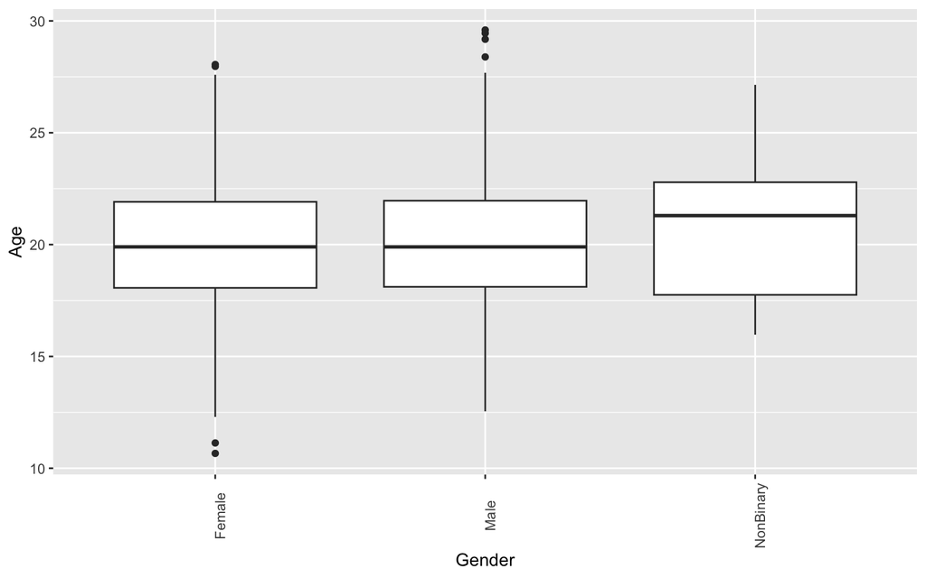

```r
library(ggplot2)
box_plot <- ggplot(data = zombie_data, aes(x = gender, y = (age)))
box_plot <- box_plot + geom_boxplot()
box_plot <- box_plot + theme(axis.text.x = element_text(angle = 90)) #I personally prefer the text to be horizontal as opposed to vertical, element_text(angle =) arg
box_plot <- box_plot + ylab("Age") + xlab("Gender") # boxplot looks solid!
box_plot
```

## Problem 2: Weight

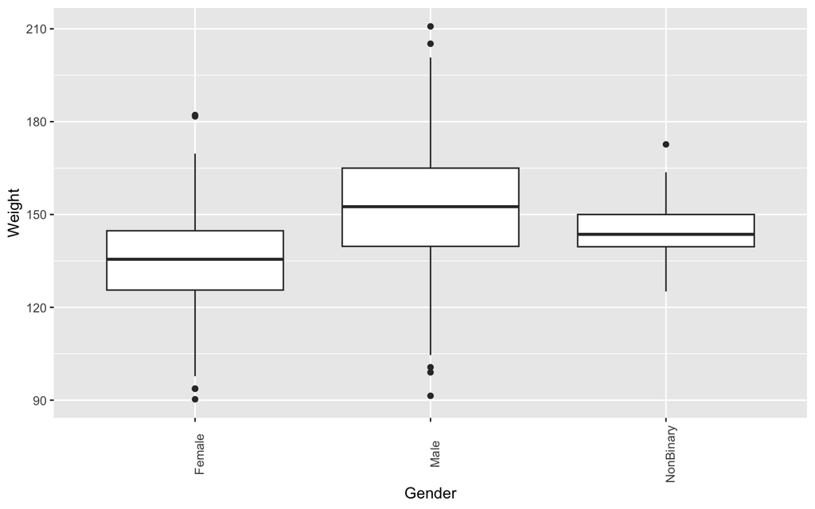

```r
library(ggplot2) # you don't need to call to ggplot2 in every chunk <3
box_plot_2 <- ggplot(data = zombie_data, aes(x = gender, y = (weight)))
box_plot_2 <- box_plot_2 + geom_boxplot()
box_plot_2 <- box_plot_2 + theme(axis.text.x = element_text(angle = 90))
box_plot_2 <- box_plot_2 + ylab("Weight") + xlab("Gender")
box_plot_2
```

## Problem 2: Height

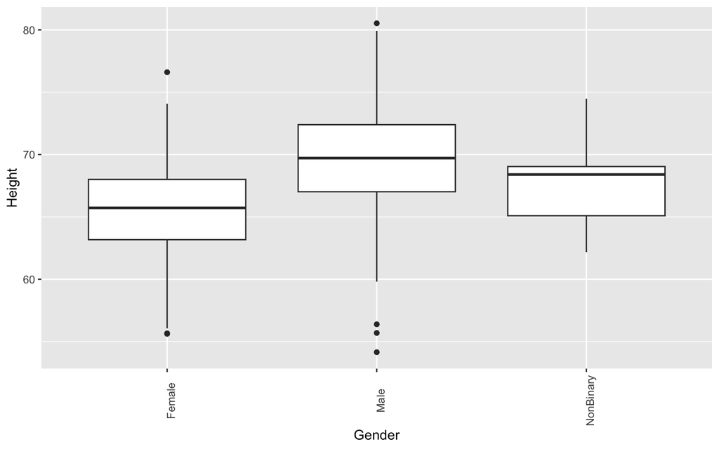

```r
library(ggplot2)
box_plot_3 <- ggplot(data = zombie_data, aes(x = gender, y = (height)))
box_plot_3 <- box_plot_3 + geom_boxplot()
box_plot_3 <- box_plot_3 + theme(axis.text.x = element_text(angle = 90))
box_plot_3 <- box_plot_3 + ylab("Height") + xlab("Gender")
box_plot_3
```

## Problem 2: Zombies Killed

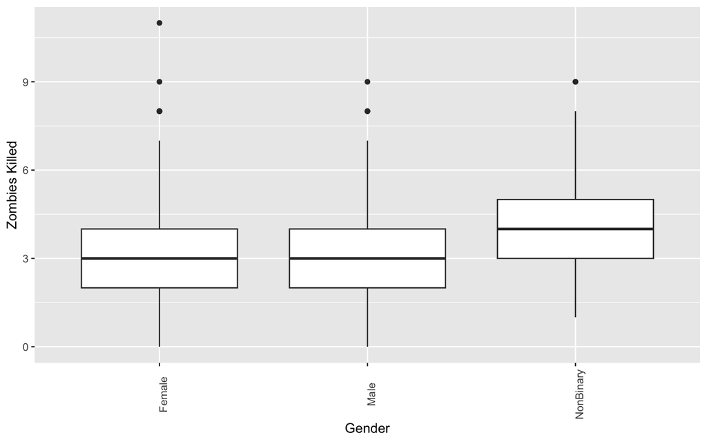

```r
library(ggplot2)
box_plot_4 <- ggplot(data = zombie_data, aes(x = gender, y = (killed)))
box_plot_4 <- box_plot_4 + geom_boxplot()
box_plot_4 <- box_plot_4 + theme(axis.text.x = element_text(angle = 90))
box_plot_4 <- box_plot_4 + ylab("Zombies Killed") + xlab("Gender")
box_plot_4
```

## Problem 2: Years of Education

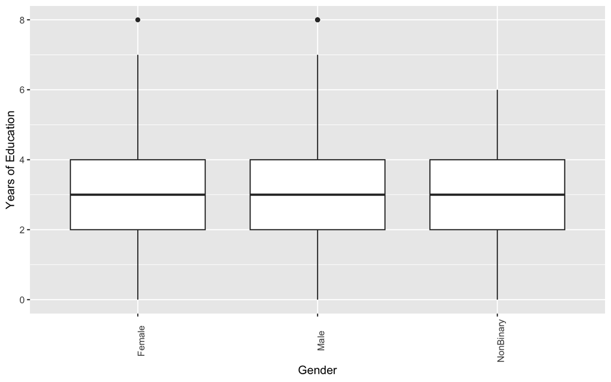

```r
library(ggplot2)
box_plot_5 <- ggplot(data = zombie_data, aes(x = gender, y = (years_of_education)))
box_plot_5 <- box_plot_5 + geom_boxplot()
box_plot_5 <- box_plot_5 + theme(axis.text.x = element_text(angle = 90))
box_plot_5 <- box_plot_5 + ylab("Years of Education") + xlab("Gender")
box_plot_5
```

## Problem 3: Height and Age

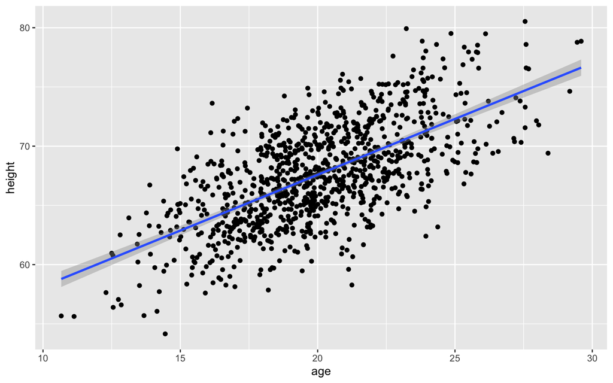

```r
scatterplot <- ggplot(data = zombie_data, aes(x = age, y = height))
scatterplot <- scatterplot + geom_point()
scatterplot <- scatterplot + geom_smooth(method = "lm") # nice linear model!
scatterplot
```

## Problem 3: Weight and Age

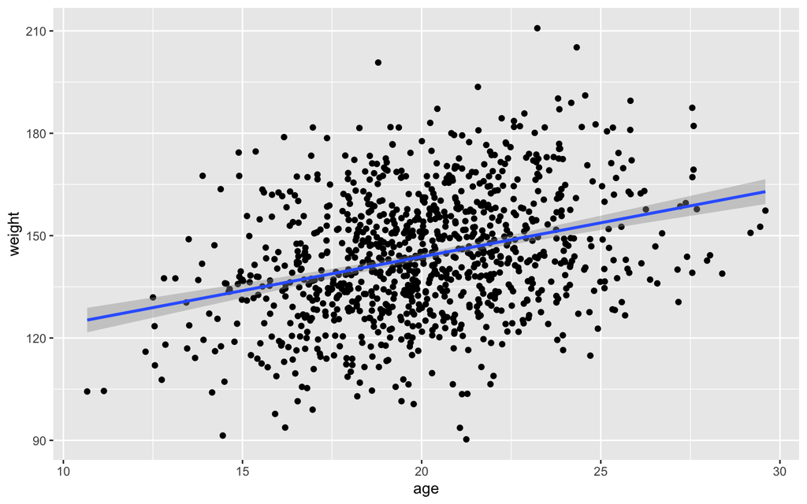

```r
scatterplot_2 <- ggplot(data = zombie_data, aes(x = age, y = weight))
scatterplot_2 <- scatterplot_2 + geom_point()
scatterplot_2 <- scatterplot_2 + geom_smooth(method = "lm")
scatterplot_2
```

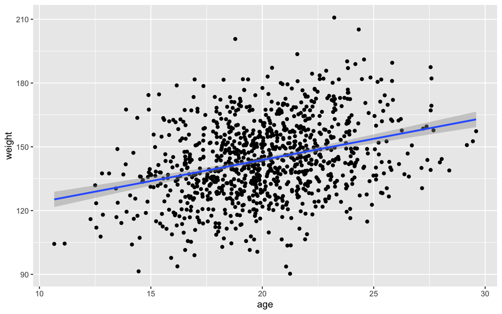

```r
scatterplot_3 <- ggplot(data = zombie_data, aes(x = age, y = weight))
scatterplot_3 <- scatterplot_3 + geom_point()
scatterplot_3 <- scatterplot_3 + geom_smooth(method = "lm")
scatterplot_3
```

## Problem 4: Age

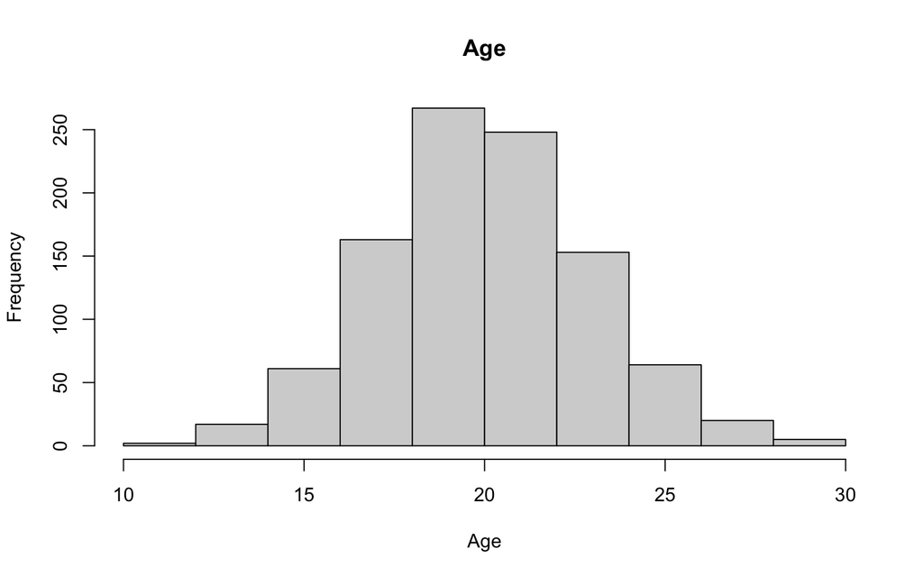

```r
hist_age <- hist(age, main = "Age",
    xlab = "Age", xlim = c(10,30))
```

```r
hist_age
```

```
## $breaks
##  [1] 10 12 14 16 18 20 22 24 26 28 30
##
## $counts
##  [1]   2  17  61 163 267 248 153  64  20   5
##
## $density
##  [1] 0.0010 0.0085 0.0305 0.0815 0.1335 0.1240 0.0765 0.0320 0.0100 0.0025
##
## $mids
##  [1] 11 13 15 17 19 21 23 25 27 29
##
## $xname
## [1] "age"
##
## $equidist
## [1] TRUE
##
## attr(,"class")
## [1] "histogram"
```

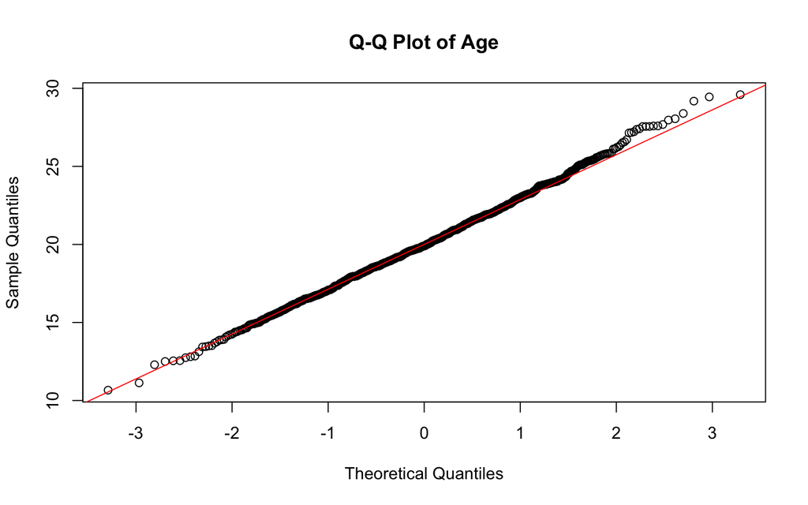

```r
qqnorm(zombie_data$age, main = "Q-Q Plot of Age")
qqline(zombie_data$age, col = "red")
```

## Problem 4: Weight

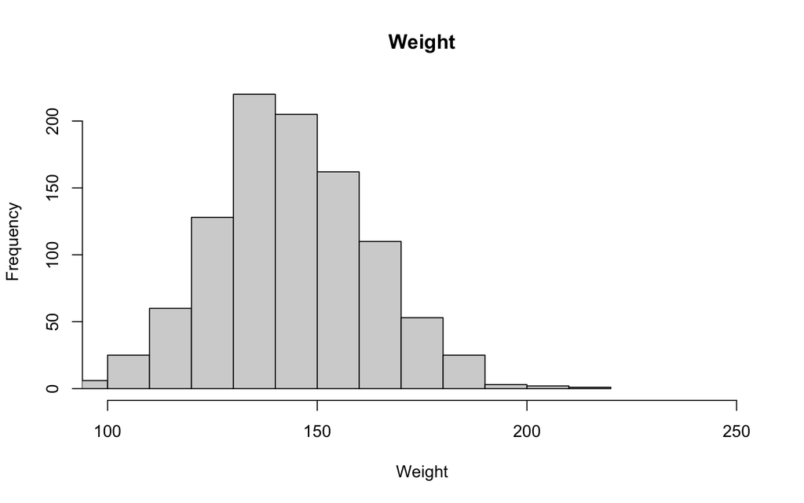

```r
hist_weight <- hist(weight, main = "Weight",
    xlab = "Weight", xlim = c(100,250))
```

```r
hist_weight
```

```
## $breaks
##  [1]  90 100 110 120 130 140 150 160 170 180 190 200 210 220
##
## $counts
##  [1]   6  25  60 128 220 205 162 110  53  25   3   2   1
##
## $density
##  [1] 0.0006 0.0025 0.0060 0.0128 0.0220 0.0205 0.0162 0.0110 0.0053 0.0025
## [11] 0.0003 0.0002 0.0001
##
## $mids
##  [1]  95 105 115 125 135 145 155 165 175 185 195 205 215
##
## $xname
## [1] "weight"
##
## $equidist
## [1] TRUE
##
## attr(,"class")
## [1] "histogram"
```

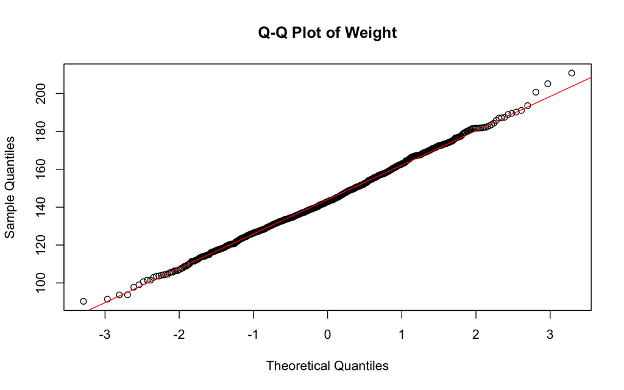

```r
qqnorm(zombie_data$weight, main = "Q-Q Plot of Weight")
qqline(zombie_data$weight, col = "red")
```

## Problem 4: Zombies Killed

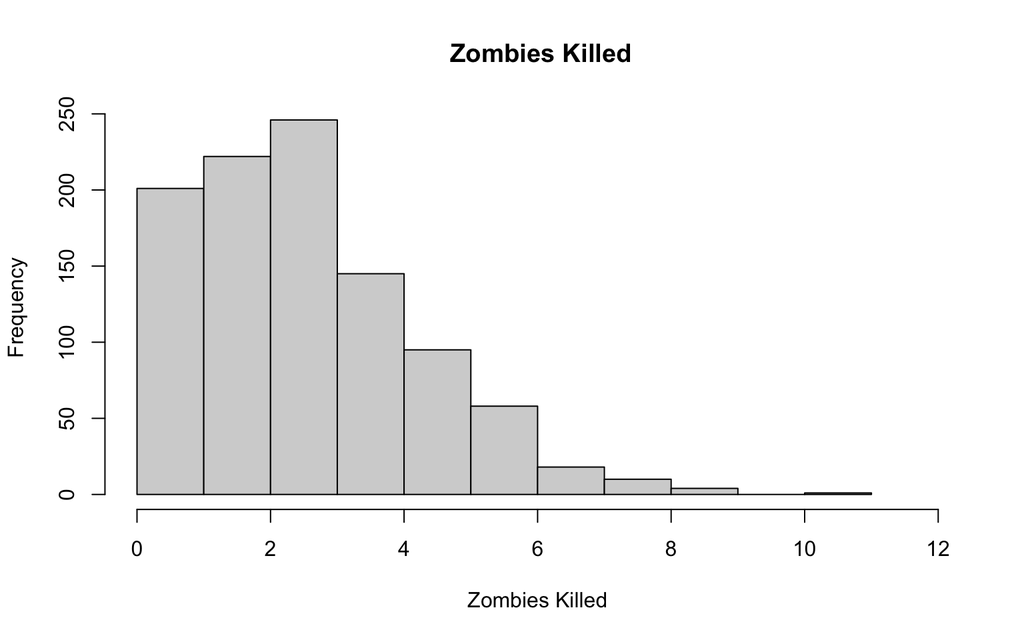

```r
hist_killed <- hist(killed, main = " Zombies Killed",
    xlab = "Zombies Killed", xlim = c(0,12))
```

```r
hist_killed
```

```
## $breaks
##  [1]  0  1  2  3  4  5  6  7  8  9 10 11
##
## $counts
##  [1] 201 222 246 145  95  58  18  10   4   0   1
##
## $density
##  [1] 0.201 0.222 0.246 0.145 0.095 0.058 0.018 0.010 0.004 0.000 0.001
##
## $mids
##  [1]  0.5  1.5  2.5  3.5  4.5  5.5  6.5  7.5  8.5  9.5 10.5
##
## $xname
## [1] "killed"
##
## $equidist
## [1] TRUE
##
## attr(,"class")
## [1] "histogram"
```

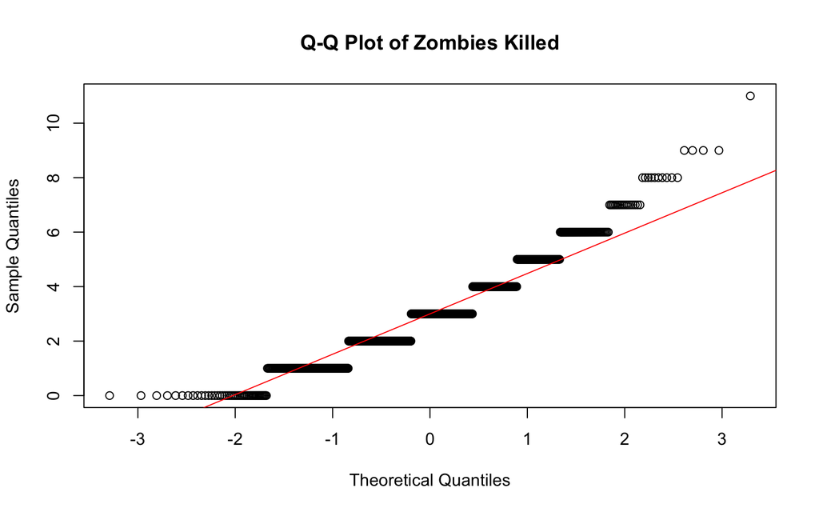

```r
qqnorm(zombie_data$zombies_killed, main = "Q-Q Plot of Zombies Killed")
qqline(zombie_data$zombies_killed, col = "red")
```

## Problem 4: Years of Education

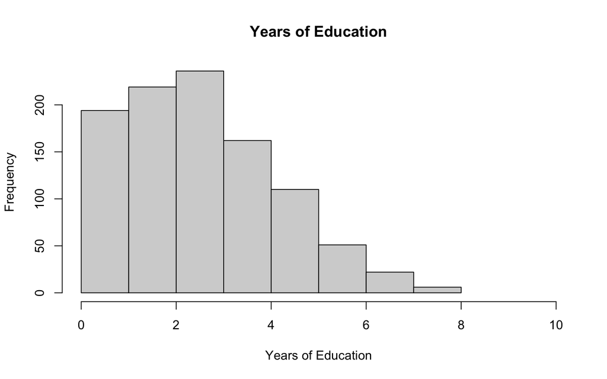

```r
hist_years <- hist(years_of_education, main = "Years of Education",
    xlab = "Years of Education", xlim = c(0,10))
```

```r
hist_years
```

```
## $breaks
## [1] 0 1 2 3 4 5 6 7 8
##
## $counts
## [1] 194 219 236 162 110  51  22   6
##
## $density
## [1] 0.194 0.219 0.236 0.162 0.110 0.051 0.022 0.006
##
## $mids
## [1] 0.5 1.5 2.5 3.5 4.5 5.5 6.5 7.5
##
## $xname
## [1] "years_of_education"
##
## $equidist
## [1] TRUE
##
## attr(,"class")
## [1] "histogram"
```

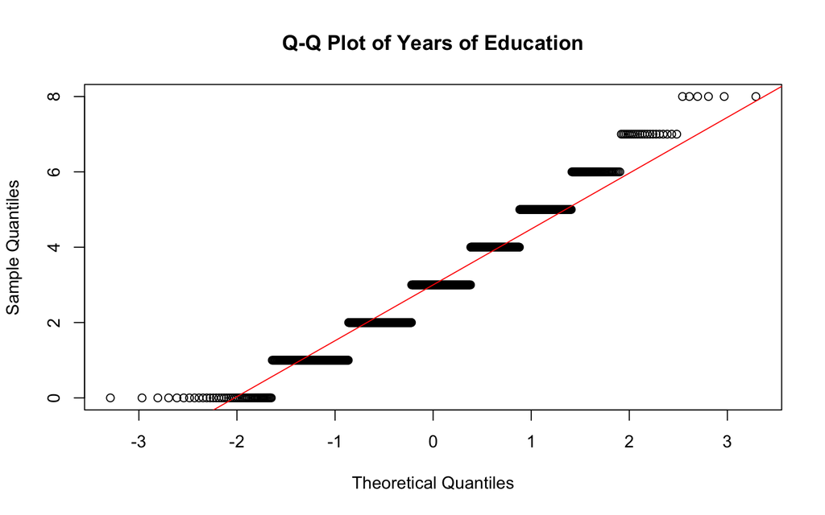

```r
qqnorm(zombie_data$years_of_education, main = "Q-Q Plot of Years of Education")
qqline(zombie_data$years_of_education, col = "red")
```

## Problem 4: Height

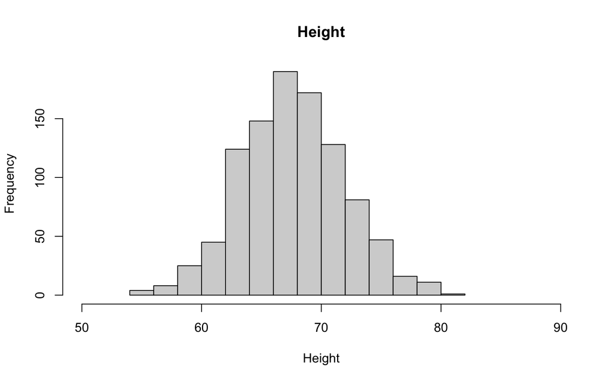

```r
hist_height <- hist(height, main = "Height",
    xlab = "Height", xlim = c(50,90))
```

```r
hist_height
```

```
## $breaks
##  [1] 54 56 58 60 62 64 66 68 70 72 74 76 78 80 82
##
## $counts
##  [1]   4   8  25  45 124 148 190 172 128  81  47  16  11   1
##
## $density
##  [1] 0.0020 0.0040 0.0125 0.0225 0.0620 0.0740 0.0950 0.0860 0.0640 0.0405
## [11] 0.0235 0.0080 0.0055 0.0005
##
## $mids
##  [1] 55 57 59 61 63 65 67 69 71 73 75 77 79 81
##
## $xname
## [1] "height"
##
## $equidist
## [1] TRUE
##
## attr(,"class")
## [1] "histogram"
```

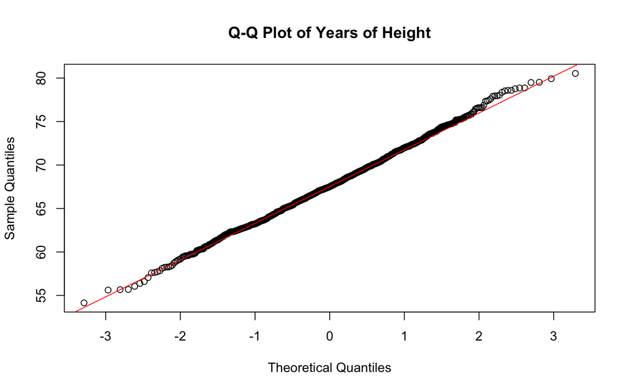

```r
qqnorm(zombie_data$height, main = "Q-Q Plot of Years of Height")
qqline(zombie_data$height, col = "red")
```

## Problem 5: Height

```r
sample_height <- sample(height, 30, replace = FALSE)
mean(sample_height)
```

```
## [1] 67.56616
```

```r
standard_dev_height <- sd(sample_height)
standard_dev_height
```

```
## [1] 3.769597
```

```r
height_sample_stand_error <- standard_dev_height/sqrt(30)
height_sample_stand_error
```

```
## [1] 0.688231
```

```r
lower <- mean_height - qnorm(1 - 0.05/2) * height_sample_stand_error # 0.975 is the same value as 1 - 0.05/2
upper <- mean_height + qnorm(1 - 0.05/2) * height_sample_stand_error # can we assume normality here? i'd personally argue no but the point of the exercise is to know when and when not to use qnorm() vs. qt() in confidence interval calculations
ci_height <- c(lower, upper)
ci_height
```

```
## [1] 66.28119 68.97901
```

```r
## I don't know why this chunk isn't included in my final knit
```

## Problem 5: Weight

```r
sample_weight <- sample(weight, 30, replace = FALSE)
mean(sample_weight)
```

```
## [1] 145.0883
```

```r
standard_dev_weight <- sd(sample_weight)
standard_dev_weight
```

```
## [1] 19.37817
```

```r
weight_sample_stand_error <- standard_dev_weight/sqrt(30)
weight_sample_stand_error
```

```
## [1] 3.537954
```

```r
lower_weight <- mean_weight - qnorm(1 - 0.05/2) * weight_sample_stand_error
upper_weight <- mean_weight + qnorm(1 - 0.05/2) * weight_sample_stand_error
ci_weight <- c(lower_weight, upper_weight)
ci_weight
```

```
## [1] 136.9732 150.8417
```

## Problem 5: Age

```r
sample_age <- sample(age, 30, replace = FALSE)
mean(sample_age)
```

```
## [1] 20.06482
```

```r
standard_dev_age <- sd(sample_age)
standard_dev_age
```

```
## [1] 2.394683
```

```r
age_sample_stand_error <- standard_dev_age/sqrt(30)
age_sample_stand_error
```

```
## [1] 0.4372073
```

```r
lower_age <- mean_age - qnorm(1 - 0.05/2) * age_sample_stand_error
upper_age <- mean_age + qnorm(1 - 0.05/2) * age_sample_stand_error
ci_age <- c(lower_age, upper_age)
ci_age
```

```
## [1] 19.19005 20.90387
```

## Problem 5: Zombies Killed

```r
sample_killed <- sample(killed, 30, replace = FALSE)
mean(sample_killed)
```

```
## [1] 2.3
```

```r
standard_dev_killed <- sd(sample_killed)
standard_dev_killed
```

```
## [1] 1.48904
```

```r
killed_sample_stand_error <- standard_dev_killed/sqrt(30)
killed_sample_stand_error
```

```
## [1] 0.2718603
```

```r
lower_killed <- mean_killed - qnorm(1 - 0.05/2) * killed_sample_stand_error # we definitely can't assume normality here, would use qt()
upper_killed <- mean_killed + qnorm(1 - 0.05/2) * killed_sample_stand_error
ci_killed <- c(lower_killed, upper_killed)
ci_killed
```

```
## [1] 2.459164 3.524836
```

## Problem 5: Years of Education

```r
sample_years <- sample(years_of_education, 30, replace = FALSE)
mean(sample_years)
```

```
## [1] 3.433333
```

```r
standard_dev_years <- sd(sample_years)
standard_dev_years
```

```
## [1] 1.568732
```

```r
years_sample_stand_error <- standard_dev_years/sqrt(30)
years_sample_stand_error
```

```
## [1] 0.2864099
```

```r
lower_years <- mean_years_of_education - qnorm(1 - 0.05/2) * years_sample_stand_error
upper_years <- mean_years_of_education + qnorm(1 - 0.05/2) * years_sample_stand_error
ci_years <- c(lower_years, upper_years)
ci_years
```

```
## [1] 2.434647 3.557353
```

## Problem 6: Height

```r
height_99 <- NULL
for (i in 1:99) {
    height_99[i] <- mean(sample(height, 30, replace = FALSE)) # head's up this is only doing 99 iterations!
}
all_100 <- c(height_99, mean(sample_height))
mean(all_100)
```

```
## [1] 67.59743
```

```r
sd(all_100) # double head's up i'm pretty sure we're supposed to be doing confidence intervals here
```

```
## [1] 0.7773139
```

## Problem 6: Weight

```r
weight_99 <- NULL
for (i in 1:99) {
    weight_99[i] <- mean(sample(weight, 30, replace = FALSE))
}
all_100_w <- c(weight_99, mean(sample_weight))
mean(all_100_w)
```

```
## [1] 143.6596
```

```r
sd(all_100_w)
```

```
## [1] 2.979015
```

## Problem 6: Age

```r
age_99 <- NULL
for (i in 1:99) {
    age_99[i] <- mean(sample(age, 30, replace = FALSE))
}
all_100_a <- c(age_99, mean(sample_age))
mean(all_100_a)
```

```
## [1] 20.06065
```

```r
sd(all_100_a)
```

```
## [1] 0.5095475
```

## Problem 6: Zombies Killed

```r
killed_99 <- NULL
for (i in 1:99) {
    killed_99[i] <- mean(sample(killed, 30, replace = FALSE))
}
all_100_k <- c(killed_99, mean(sample_killed))
mean(all_100_k)
```

```
## [1] 2.997333
```

```r
sd(all_100_k)
```

```
## [1] 0.3495927
```

## Problem 6: Years of Education

```r
years_99 <- NULL
for (i in 1:99) {
    years_99[i] <- mean(sample(years_of_education, 30, replace = FALSE))
}
all_100_y <- c(years_99, mean(sample_years))
mean(all_100_y)
```

```
## [1] 3.011
```

```r
sd(all_100_y)
```

```
## [1] 0.3398044
```